# [Введение в анализ данных](https://thetahat.ru/courses/ad)

В качестве цветовой палитры выбрана `"RdBu"`, что позволяет отображать положительные числа матрицы красным цветом, а отрицательные — синим. Чтобы достичь этого, также **необходимо установить параметры `vmin` и `vmax`** симметрично относительно нуля, чтобы нули отображались белым цветом. Подберите эти значения таким образом, чтобы получить наиболее четкую картинку, на которой выделяются определенные группы пикселей.

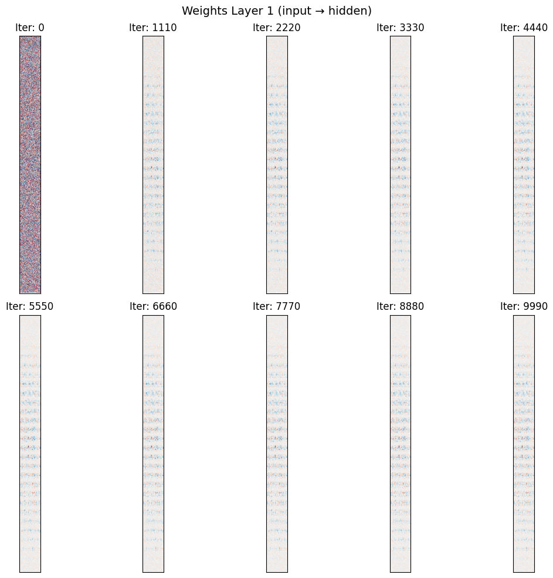

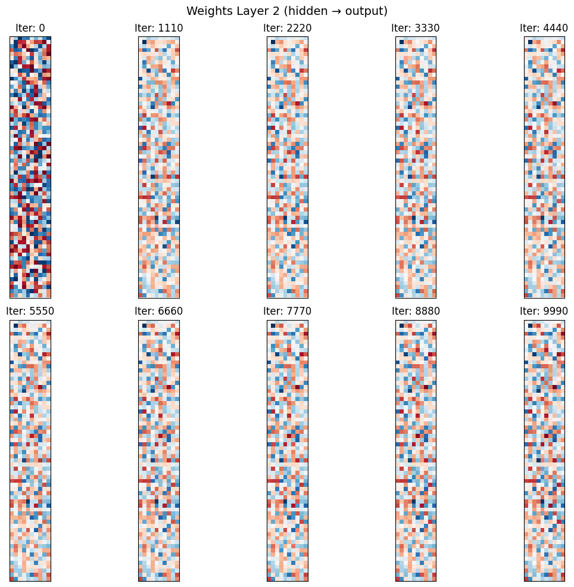

```python
iterations_to_plot = np.linspace(0, len(model_weights["weights_layer_1"]) - 1, 10, dtype=int)

plt.figure(figsize=(12, 10))
for i, iter_num in enumerate(iterations_to_plot):
    plt.subplot(2, 5, i + 1)

    weights = model_weights["weights_layer_1"][iter_num].T

    vmax = np.max(np.abs(weights))
    vmin = -vmax

    plt.imshow(weights, cmap="RdBu", vmin=vmin, vmax=vmax)
    plt.title(f"Iter: {history[iter_num][1]}")
    plt.xticks([])
    plt.yticks([])

plt.suptitle("Weights Layer 1 (input → hidden)", fontsize=14)
plt.tight_layout()
plt.show()

plt.figure(figsize=(12, 10))
for i, iter_num in enumerate(iterations_to_plot):
    plt.subplot(2, 5, i + 1)

    weights = model_weights["weights_layer_2"][iter_num].T
    vmax = np.max(np.abs(weights))
    vmin = -vmax

    plt.imshow(weights, cmap="RdBu", vmin=vmin, vmax=vmax)
    plt.title(f"Iter: {history[iter_num][1]}")
    plt.xticks([])
    plt.yticks([])

plt.suptitle("Weights Layer 2 (hidden → output)", fontsize=14)
plt.tight_layout()
plt.show()
```

Какие выводы можно сделать, основываясь на полученных визуализациях? Подумайте, почему на больших итерациях для первого слоя начинают выделяться определенные пиксели? Почему именно эти пиксели?

*Подсказка: вспомните, как устроены входные изображения цифр, с которыми мы работаем.*

**Ответ:**

В обоих слоях обучение началось со случайно инициализированных коэффициентов: это и видно на графике. По мере обучения, коэффициенты приобретали структуру, к концу обучения начали выделяться пиксели: оно и логично, это именно то, чего мы хотели от модели — анализ писклей.

Попробуйте **улучшить точность классификации**, рассмотрев больше нейронов в промежуточном слое.

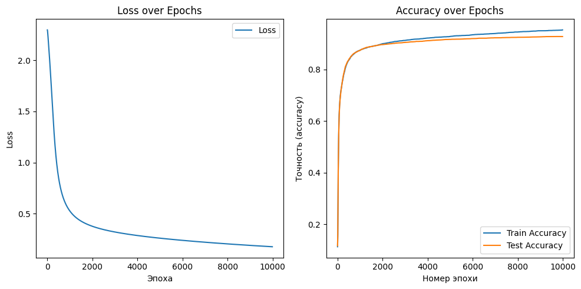

```
Лучшая точность (accuracy) на тесте: 0.9283
```

```python
model = Net(train_images.shape[1], hidden_size=1024)
model = model.to(device)

criterion = nn.CrossEntropyLoss()
optimizer = optim.SGD(model.parameters(), lr=0.001, momentum=0.9)

inputs = train_images.clone().detach().to(device)
labels = train_labels.clone().detach().to(device)

inputs_test = test_images.clone().detach().to(device)
labels_test = test_labels.clone().detach().to(device)

history = []

model_weights = {
    "weights_layer_1": [],
    "weights_layer_2": [],
    "bias_layer_1": [],
    "bias_layer_2": [],
}

for epoch in range(10_000):
    output = model(inputs)
    loss = criterion(output, labels)

    optimizer.zero_grad()
    loss.backward()
    optimizer.step()

    if epoch % 10 == 0:
        with torch.no_grad():
            test_output = model(inputs_test)

        train_accuracy = accuracy_score(labels.cpu().numpy(), torch.argmax(output, dim=1).cpu().numpy())
        test_accuracy = accuracy_score(labels_test.cpu().numpy(), torch.argmax(test_output, dim=1).cpu().numpy())

        model_weights["weights_layer_1"].append(model.fc1.weight.data.cpu().numpy().copy())
        model_weights["weights_layer_2"].append(model.fc2.weight.data.cpu().numpy().copy())
        model_weights["bias_layer_1"].append(model.fc1.bias.data.cpu().numpy().copy())
        model_weights["bias_layer_2"].append(model.fc2.bias.data.cpu().numpy().copy())

        history.append((loss.item(), epoch, train_accuracy, test_accuracy))

plt.figure(figsize=(10, 5))

plt.subplot(1, 2, 1)
plt.plot([h[1] for h in history], [h[0] for h in history], label="Loss")
plt.xlabel("Эпоха")
plt.ylabel("Loss")
plt.title("Loss over Epochs")
plt.legend()

# График точности
test_accuracy = [h[3] for h in history]
train_accuracy = [h[2] for h in history]

plt.subplot(1, 2, 2)
plt.plot([h[1] for h in history], train_accuracy, label="Train Accuracy")
plt.plot([h[1] for h in history], test_accuracy, label="Test Accuracy")
plt.xlabel("Номер эпохи")
plt.ylabel("Точность (accuracy)")
plt.title("Accuracy over Epochs")
plt.legend()

plt.tight_layout()
plt.show()

print(f"Лучшая точность (accuracy) на тесте: {max(test_accuracy)}")
```

Теперь попробуйте добавить к сети еще один слой.

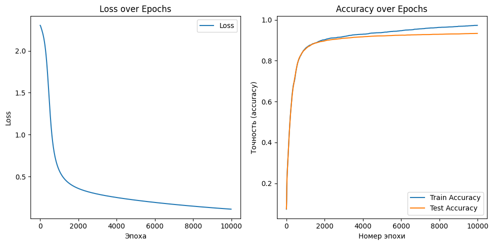

```
Лучшая точность (accuracy) на тесте: 0.9335
```

```python
class Net(nn.Module):
    def __init__(self, input_size, hidden_size, count_of_classes=10):
        super(Net, self).__init__()
        self.fc1 = nn.Linear(input_size, hidden_size)
        self.fc2 = nn.Linear(hidden_size, hidden_size)
        self.fc3 = nn.Linear(hidden_size, count_of_classes)

    def forward(self, x):
        x = nn.functional.relu(self.fc1(x))
        x = nn.functional.relu(self.fc2(x))
        x = self.fc3(x)
        return x


model = Net(train_images.shape[1], hidden_size=1024)
model = model.to(device)

model = Net(train_images.shape[1], hidden_size=1024)
model = model.to(device)

criterion = nn.CrossEntropyLoss()
optimizer = optim.SGD(model.parameters(), lr=0.001, momentum=0.9)

inputs = train_images.clone().detach().to(device)
labels = train_labels.clone().detach().to(device)

inputs_test = test_images.clone().detach().to(device)
labels_test = test_labels.clone().detach().to(device)

history = []

model_weights = {
    "weights_layer_1": [],
    "weights_layer_2": [],
    "bias_layer_1": [],
    "bias_layer_2": [],
}

for epoch in range(10_000): # Обучение заняло 50 секунд
    output = model(inputs)
    loss = criterion(output, labels)

    optimizer.zero_grad()
    loss.backward()
    optimizer.step()

    if epoch % 10 == 0:
        with torch.no_grad():
            test_output = model(inputs_test)

        train_accuracy = accuracy_score(labels.cpu().numpy(), torch.argmax(output, dim=1).cpu().numpy())
        test_accuracy = accuracy_score(labels_test.cpu().numpy(), torch.argmax(test_output, dim=1).cpu().numpy())

        model_weights["weights_layer_1"].append(model.fc1.weight.data.cpu().numpy().copy())
        model_weights["weights_layer_2"].append(model.fc2.weight.data.cpu().numpy().copy())
        model_weights["bias_layer_1"].append(model.fc1.bias.data.cpu().numpy().copy())
        model_weights["bias_layer_2"].append(model.fc2.bias.data.cpu().numpy().copy())

        history.append((loss.item(), epoch, train_accuracy, test_accuracy))

plt.figure(figsize=(10, 5))

plt.subplot(1, 2, 1)
plt.plot([h[1] for h in history], [h[0] for h in history], label="Loss")
plt.xlabel("Эпоха")
plt.ylabel("Loss")
plt.title("Loss over Epochs")
plt.legend()

# График точности
test_accuracy = [h[3] for h in history]
train_accuracy = [h[2] for h in history]

plt.subplot(1, 2, 2)
plt.plot([h[1] for h in history], train_accuracy, label="Train Accuracy")
plt.plot([h[1] for h in history], test_accuracy, label="Test Accuracy")
plt.xlabel("Номер эпохи")
plt.ylabel("Точность (accuracy)")
plt.title("Accuracy over Epochs")
plt.legend()

plt.tight_layout()
plt.show()

print(f"Лучшая точность (accuracy) на тесте: {max(test_accuracy)}")
```

Насколько дольше обучается нейросеть? Получилось ли улучшить качество?

**Ответ:**

Я сделал два теста: с сигмойдным слоем и RELU

Сигмоида:

[output not shown]

RELU:

[output not shown]

Сделайте выводы.

**Ответ:**

В данной задаче эффективнее использовать RELU. Это может объясняться несколькими проблемами: затухающие градиенты, ненормированные данные и несимметричность активации (это не входит в программу курса).

Нередко качество модели обусловлено количеством параметров, чем больше, тем лучше (можно посмотреть на примере GPT-1 -> GPT-2, где фактически только увеличили количество параметров в более чем сотню раз), что, собственно и подтвердила моё решение. Но эксперимент с сигмоидой также показал, что даже значительно бОльшая модель может работать хуже (можно привести пример Qwen -> GPT-3. Qwen имеет намного меньше параметров, но при этом значительно превосходящее качество).

Также можно увидеть, что для обучения даже небольших нейеросетей требуется GPU и некоторое время, поэтому ошибки могут стоить особенно дорого. (Еще можно сказать про визуализацию: модель выделяет пиксели со временем).

Благодаря универсальности, (видно, что мы не применяли никаких уникальных методов к задаче) нейеросети становятся всё популярнее.

**Мы продолжим работу с нейросетями во второй части этого домашнего задания, которую вы можете сдать на неделю позже первой.**

Вы могли заметить, что качество наших моделей было не таким высоким, как можно было бы получить современными моделями. Тем не менее отметим, что сравнивать с моделью KNN, которую мы рассмотрели на первом занятии, было бы некорректно, так как там использовалась более простая выборка.

Обучение нейронных сетей — это довольно сложная задача. Чтобы глубокие сети обучались более стабильно, используются специальные технологии, изучение которых требует больших усилий. Например, на следующей лекции мы рассмотрим сверточные слои и другие подходы к созданию и обучению нейросетей для анализа изображений. Полное погружение в мир нейросетей, включая самые современные архитектуры, ожидает вас на третьем курсе. Например, на DS-потоке будет порядка 14 лекций по этой теме.

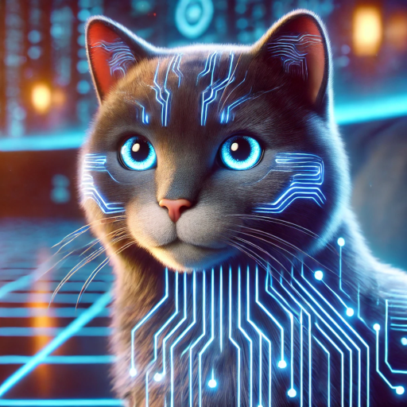